# Case Study 10

Lorenzo Leme

March 28, 2020

```r
# Use this R-Chunk to import all your datasets!
```

## Background

You have been asked to support a story for the local paper (that has a web presence) that looks back on the housing collapse and the early effects of residential construction. You have data on residential building permits from 1980 through 2010 for each county in the United States. Your colleague that is writing the article would like a few maps and graphics that highlight the single family building permit patterns across your state as well as the patterns in the US.

Remember the big story is the collapse of new building permits at the initial stages of the mortgage crisis. Make sure your graphics highlight the collapse in a clear and honest manner.

## Data Wrangling

```r
# Use this R-Chunk to clean & wrangle your data!
#MARKET CRASH 07-12

VA_county <- us_counties() %>%
  filter(state_abbr == "VA") %>%
  mutate(countyfp = parse_number(countyfp)) %>%
  unique()

builds <- permits %>%
  rename(state_abbr = "StateAbbr") %>%
  rename(statefp = "state") %>%
  rename(countyfp = "county") %>%
  filter(state_abbr != "AK" & state_abbr != "HI" & state_abbr != "PR") %>%
  filter(variable == "Single Family") %>%
  filter(year %in% c(2003, 2004, 2005, 2006, 2007, 2008)) %>%
  unique()


builds <- permits %>%
  filter(StateAbbr=="VA") %>%
  rename(state_abbr = "StateAbbr") %>%
  rename(statefp = "state") %>%
  rename(countyfp = "county")


crash <- builds %>%
  filter(year %in% c(2006, 2007, 2008, 2009, 2010))

VA <- inner_join(VA_county, crash, by = "countyfp") %>%
  select(countyfp, countyname, year, value, geometry) %>%
  group_by(countyfp, year) %>%
  mutate(total = sum(value)) %>%
  mutate(total = as.numeric(total))

fairfax <- VA %>%
  filter(countyname == "Fairfax County")
```

## Data Visualization

### Virginia

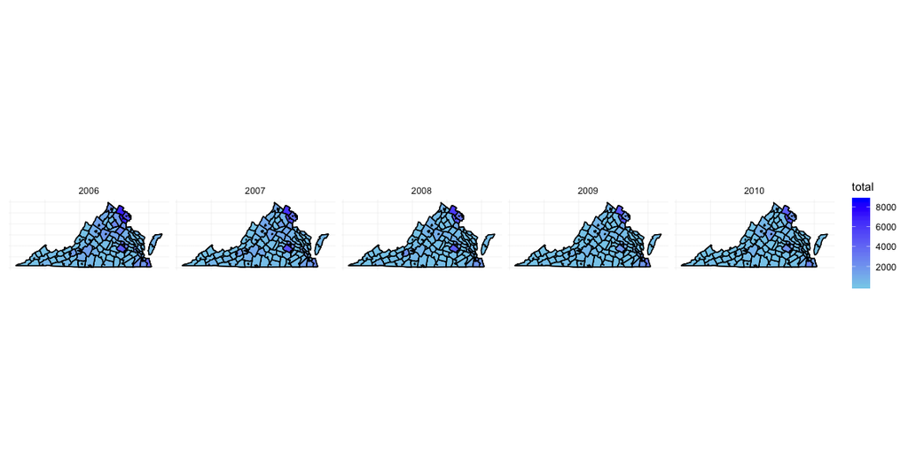

```r
# Use this R-Chunk to plot & visualize your data!
ggplot(data = VA)+
  geom_sf(aes(fill = total), color = "black")+
  facet_grid(~ year)+
  theme_minimal()+
  scale_fill_gradient(low = "skyblue", high = "blue", space = "Lab", guide = "colourbar", aesthetics = "fill") +
    theme(axis.title.x=element_blank(), axis.text.x=element_blank(), axis.ticks.x=element_blank(),
          axis.title.y=element_blank(), axis.text.y=element_blank(), axis.ticks.y=element_blank())
```

### Fairfax County

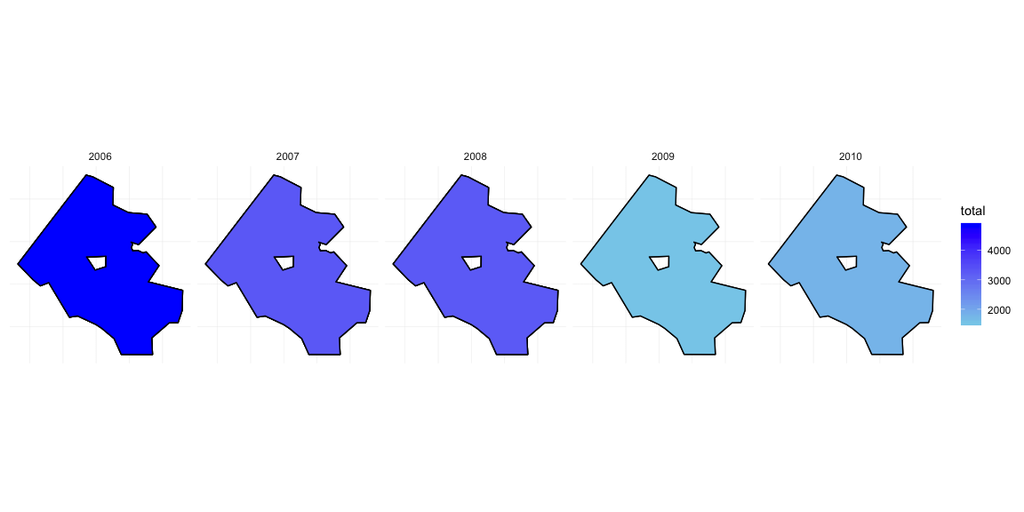

```r
ggplot(data = fairfax)+
  geom_sf(aes(fill = total), color = "black")+
  facet_grid(~ year)+
  theme_minimal()+
  scale_fill_gradient(low = "skyblue", high = "blue", space = "Lab", guide = "colourbar", aesthetics = "fill") +
    theme(axis.title.x=element_blank(), axis.text.x=element_blank(), axis.ticks.x=element_blank(),
          axis.title.y=element_blank(), axis.text.y=element_blank(), axis.ticks.y=element_blank())
```

## Conclusions

The collapse of the market lasted from 2007-2010. In our graphics we’ll start looking from a year before the crash, 2006. This will give us a good reference point.